# Análisis Base de Datos Simplificada

Tomás Sánchez Grigioni

13/9/2020

# Análisis de Datos

Las variables con las que se va a trabajar son:

| Nombre Variable Original | Nombre Variable Nuevo | Significado | Tipo Variable |
| --- | --- | --- | --- |
| healthCode | - | - | - |
| healthCode1 | - | Es el identificador del paciente | - |
| ROW_ID | id | Es el identificador de fila | - |
| DIAGNOSTICO | diagnostico | Resultado del diagnóstico | Categórica |
| d1 | d1 | Mean of logarithmic F0 on a semitone frequency scale | Continua |
| d2 | d2 | Mean of the ratio of the energy of the spectral harmonic peak at the first formant’s center frequency to the energy of the spectral peak at F0 in voiced regions | Continua |
| d3 | d3 | Coefficient of variation of the ratio of the energy of the spectral harmonic peak at the first formant’s center frequency to the energy of the spectral peak at F0 in voiced regions | Continua |
| d4 | d4 | Mean of linear regression slope of the logarithmic power spectrum within 0–500 Hz band entropy. | Continua |
| d5 | d5 | Mean Jitter of the deviations in individual consecutive F0 period lengths. | Continua |
| medTimePoint | punto_medicacion | Punto de toma de medicación | Cualitativa |
| age | edad | Edad del paciente | Discreta |
| are-caretaker | cuidado | Esta con cuidado | Cualitativa |
| deep-brain-stimulation | estimulacion_cerebral | Presenta el tratamiento de estimulación cerebral | Cualitativa |
| diagnosis-year | anio_diagnostico | Año en que le diagnosticaron la enfermedad | Discreta |
| education | educacion | Nivel de educacion | Cualitativa |
| employment | trabajo | Trabajo del paciente | Cualitativa |
| gender | genero | Genero del paciente | Cualitativa |
| maritalStatus | estado_civil | Estado civil | Cualitativa |
| medication-start-year | anio_medicacion | Año en que comenzo a medicarse | Discreta |
| onset-year | anio_enfermedad | Año en que se manifesto la enfermedad | Discreta |
| smartphone | facilidad_celular | Facilidad con la que usa el celular | Cualitativa |
| smoked | fumo | Si fumo | Cualitativa |
| surgery | cirugias | Si presenta cirugías | Cualitativa |
| years-smoking | anios_fumo | Cantidad de años que fumo | Discreta |

Primero cargamos los datos, luego observamos como los trata R.

```
## [1] 0
```

```
## [1] 139
```

```
## # A tibble: 406 x 32
##    healthCode1 medTimepoint `F0semitoneFrom~ `F0semitoneFrom~ `F0semitoneFrom~
##    <chr>       <chr>                   <dbl>            <dbl>            <dbl>
##  1 ae49bf2a-8~ I don't tak~             23.7          0.563               14.3
##  2 ae49bf2a-8~ I don't tak~             23.7          0.563               14.3
##  3 ae49bf2a-8~ I don't tak~             23.7          0.563               14.3
##  4 ae49bf2a-8~ I don't tak~             22.6          0.0813              22.1
##  5 4a318f75-f~ Another time             31.0          0.0165              30.7
##  6 4a318f75-f~ Another time             31.0          0.0165              30.7
##  7 84cdec84-5~ Another time             36.3          0.00818             36.1
##  8 84cdec84-5~ Another time             36.3          0.00818             36.1
##  9 84cdec84-5~ Another time             36.3          0.00818             36.1
## 10 e8b3b9a4-a~ Another time             21.7          0.239               18.0
## # ... with 396 more rows, and 27 more variables:
## #   `F0semitoneFrom27#5Hz_sma3nz_percentile50#0` <dbl>,
## #   `F0semitoneFrom27#5Hz_sma3nz_percentile80#0` <dbl>,
## #   `F0semitoneFrom27#5Hz_sma3nz_pctlrange0-2` <dbl>,
## #   `F0semitoneFrom27#5Hz_sma3nz_meanRisingSlope` <dbl>,
## #   `F0semitoneFrom27#5Hz_sma3nz_stddevRisingSlope` <dbl>,
## #   `F0semitoneFrom27#5Hz_sma3nz_meanFallingSlope` <dbl>,
## #   `F0semitoneFrom27#5Hz_sma3nz_stddevFallingSlope` <dbl>,
## #   jitterLocal_sma3nz_amean <dbl>, jitterLocal_sma3nz_stddevNorm <dbl>,
## #   shimmerLocaldB_sma3nz_amean <dbl>, shimmerLocaldB_sma3nz_stddevNorm <dbl>,
## #   ROW_ID <dbl>, age <dbl>, `are-caretaker` <chr>,
## #   `deep-brain-stimulation` <chr>, `diagnosis-year` <chr>, education <chr>,
## #   employment <chr>, gender <chr>, maritalStatus <chr>,
## #   `medication-start-year` <chr>, `onset-year` <chr>, smartphone <chr>,
## #   smoked <chr>, surgery <chr>, `years-smoking` <chr>, healthCode <chr>
```

```
## [1] 0
```

```
## $id
## [1] "numeric"
##
## $diagnostico
## [1] "numeric"
##
## $d1
## [1] "numeric"
##
## $d2
## [1] "numeric"
##
## $d3
## [1] "numeric"
##
## $d4
## [1] "numeric"
##
## $d5
## [1] "numeric"
##
## $healthCode1
## [1] "character"
##
## $punto_medicacion
## [1] "character"
##
## $`F0semitoneFrom27#5Hz_sma3nz_amean`
## [1] "numeric"
##
## $`F0semitoneFrom27#5Hz_sma3nz_stddevNorm`
## [1] "numeric"
##
## $`F0semitoneFrom27#5Hz_sma3nz_percentile20#0`
## [1] "numeric"
##
## $`F0semitoneFrom27#5Hz_sma3nz_percentile50#0`
## [1] "numeric"
##
## $`F0semitoneFrom27#5Hz_sma3nz_percentile80#0`
```

[output cut: 58 more lines]

```
##
## $facilidad_celular
## [1] "character"
##
## $fumo
## [1] "character"
##
## $cirugias
## [1] "character"
##
## $anios_fumo
## [1] "character"
##
## $healthCode
## [1] "character"
```

Los problemas que encontramos son:

- **diagnostico** no es un factor.
- **punto_medicacion** no es un factor.
- **cuidado** no es un factor.
- **estimulacion_cerebral** no es un factor.
- **anio_diagnostico** no es una fecha.
- **educacion** no es un factor.
- **trabajo** no es un factor.
- **genero** no es un factor.
- **estado_civil** no es un factor.
- **anio_medicacion** no es una fecha
- **anio_enfermedad** no es una fecha.
- **facilidad_celular** no es un factor.
- **fumo** no es un factor.
- **cirugias** no es un factor.
- **anios_fumo** no es un número.
- Además le cambiamos lo nombres a las variables para que sea más manejable.

```
## $id
## [1] "numeric"
##
## $diagnostico
## [1] "factor"
##
## $d1
## [1] "numeric"
##
## $d2
## [1] "numeric"
##
## $d3
## [1] "numeric"
##
## $d4
## [1] "numeric"
##
## $d5
## [1] "numeric"
##
## $healthCode1
## [1] "character"
##
## $punto_medicacion
## [1] "factor"
##
## $`F0semitoneFrom27#5Hz_sma3nz_amean`
## [1] "numeric"
##
## $`F0semitoneFrom27#5Hz_sma3nz_stddevNorm`
## [1] "numeric"
##
## $`F0semitoneFrom27#5Hz_sma3nz_percentile20#0`
## [1] "numeric"
##
## $`F0semitoneFrom27#5Hz_sma3nz_percentile50#0`
## [1] "numeric"
##
## $`F0semitoneFrom27#5Hz_sma3nz_percentile80#0`
```

[output cut: 58 more lines]

```
##
## $facilidad_celular
## [1] "factor"
##
## $fumo
## [1] "factor"
##
## $cirugias
## [1] "factor"
##
## $anios_fumo
## [1] "numeric"
##
## $healthCode
## [1] "character"
```

Ahora las variables se tratan correctamente. Calculamos las medidas resumen para las variables cuantitativas y creamos tablas de frecuencia para variables cualitativas

Medidas Resumen de Variables Cuantitativas

|  | Media | Mediana | Primer_Cuartil | Tercer_Cuartil | Desvio | NAs |
| --- | --- | --- | --- | --- | --- | --- |
| d1 | 27.59 | 26.54 | 23.90 | 30.94 | 5.03 | 0 |
| d2 | -12.59 | -5.98 | -16.87 | 1.40 | 26.36 | 0 |
| d3 | 0.23 | 0.21 | 0.12 | 0.33 | 0.13 | 0 |
| d4 | 0.09 | 0.09 | 0.07 | 0.10 | 0.02 | 0 |
| d5 | 0.02 | 0.01 | 0.01 | 0.02 | 0.02 | 0 |
| F0semitoneFrom27#5Hz_sma3nz_amean | 27.59 | 26.54 | 23.90 | 30.94 | 5.03 | 0 |
| F0semitoneFrom27#5Hz_sma3nz_stddevNorm | 0.07 | 0.05 | 0.01 | 0.11 | 0.07 | 0 |
| F0semitoneFrom27#5Hz_sma3nz_percentile20#0 | 26.70 | 25.63 | 22.81 | 30.38 | 5.33 | 0 |
| F0semitoneFrom27#5Hz_sma3nz_percentile50#0 | 27.44 | 26.40 | 23.53 | 31.17 | 5.35 | 0 |
| F0semitoneFrom27#5Hz_sma3nz_percentile80#0 | 28.43 | 27.36 | 24.30 | 32.34 | 5.53 | 0 |
| F0semitoneFrom27#5Hz_sma3nz_pctlrange0-2 | 1.74 | 0.46 | 0.31 | 0.90 | 3.40 | 0 |
| F0semitoneFrom27#5Hz_sma3nz_meanRisingSlope | 98.65 | 59.42 | 4.53 | 144.77 | 143.55 | 0 |
| F0semitoneFrom27#5Hz_sma3nz_stddevRisingSlope | 84.07 | 43.13 | 2.40 | 109.15 | 144.97 | 0 |
| F0semitoneFrom27#5Hz_sma3nz_meanFallingSlope | 57.49 | 26.12 | 4.01 | 84.53 | 89.79 | 0 |
| F0semitoneFrom27#5Hz_sma3nz_stddevFallingSlope | 57.40 | 24.08 | 2.94 | 73.33 | 96.93 | 0 |
| jitterLocal_sma3nz_amean | 0.02 | 0.01 | 0.01 | 0.02 | 0.02 | 0 |
| jitterLocal_sma3nz_stddevNorm | 1.94 | 1.79 | 1.18 | 2.50 | 0.99 | 0 |
| shimmerLocaldB_sma3nz_amean | 0.78 | 0.63 | 0.40 | 0.97 | 0.58 | 0 |
| shimmerLocaldB_sma3nz_stddevNorm | 0.90 | 0.82 | 0.67 | 1.06 | 0.32 | 0 |
| edad | 53.62 | 53.00 | 43.00 | 63.00 | 12.32 | 0 |
| anio_diagnostico | 2009.73 | 2011.00 | 2007.00 | 2013.00 | 4.77 | 1287 |
| anio_medicacion | 1429.44 | 2009.00 | 0.00 | 2013.00 | 911.21 | 1006 |
| anio_enfermedad | 2007.91 | 2010.00 | 2006.00 | 2012.00 | 6.24 | 1120 |
| anios_fumo | 14.32 | 12.00 | 5.00 | 20.00 | 11.14 | 1471 |

De las variables cuantitativas los problemas que se encuentran son que:

- **anio_medicacion** presenta una media en 1429.44 indicando que hay valores muy chicos que distorsionan la verdadera media. Luego, observamos que el primer cuartil tiene valor 0. Estos valores es posible que indiquen que esa persona no toma medicaciones y en su lugar se debería reemplazar estas observaciones con NA para que no interfieran.

Realizamos algunas verificaciones para determinar que no hay otros errores de este estilo.

Por la presencia de los 0s en la variable **anios_fumo** decidimos reemplazarlos por NAs. Además, completamos con NAs aquellos valores que sean anteriores a 1960 en la variable **anio_medicacion**.

## Análisis Univariado

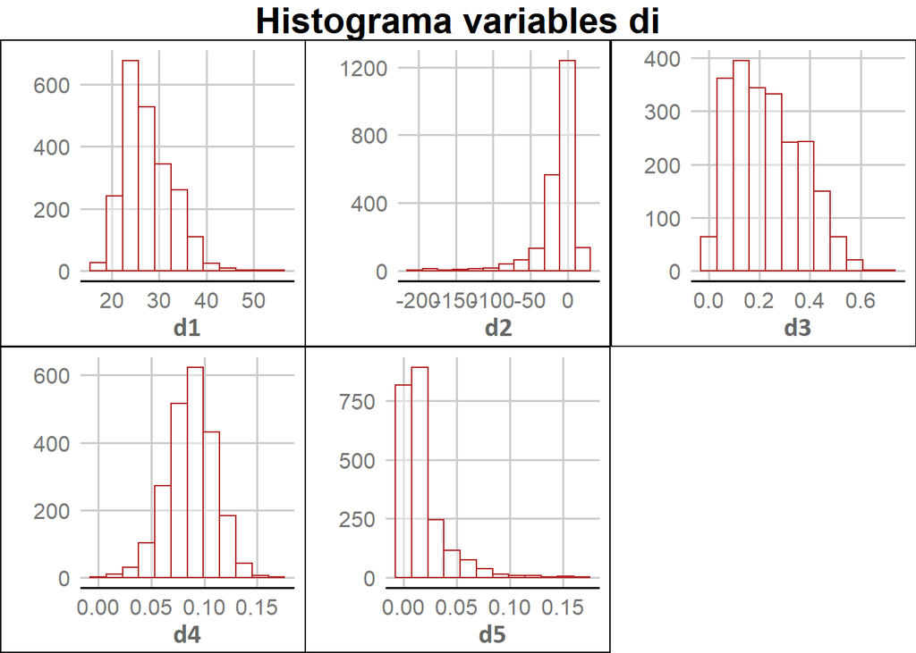

- En **d1** parece ser que los datos se concentran entre los valores de 20 y 40, teniendo algunas observaciones por fuera de este intervalo.
- En **d2** los datos parecen estar centrados en 0, pero presenta una cola con algunas observaciones para los números negativos.
- En **d3** todas las observaciones se encuentran distribuidas entre 0 y 0.6, con gran cantidad de observaciones en los valores intermedios.
- En **d4** todas las observaciones se encuentran distribuidas entre 0 y 0.15, pero con mayor cantidad de observaciones para los valores que se encuentran entre 0.05 0.10.
- En **d5** se presenta la mayor cantidad de observaciones en los valores más cercanos a 0 de esta variable. Teniendo también observaciones para valores mayores a 0.10, pero en menor medida.

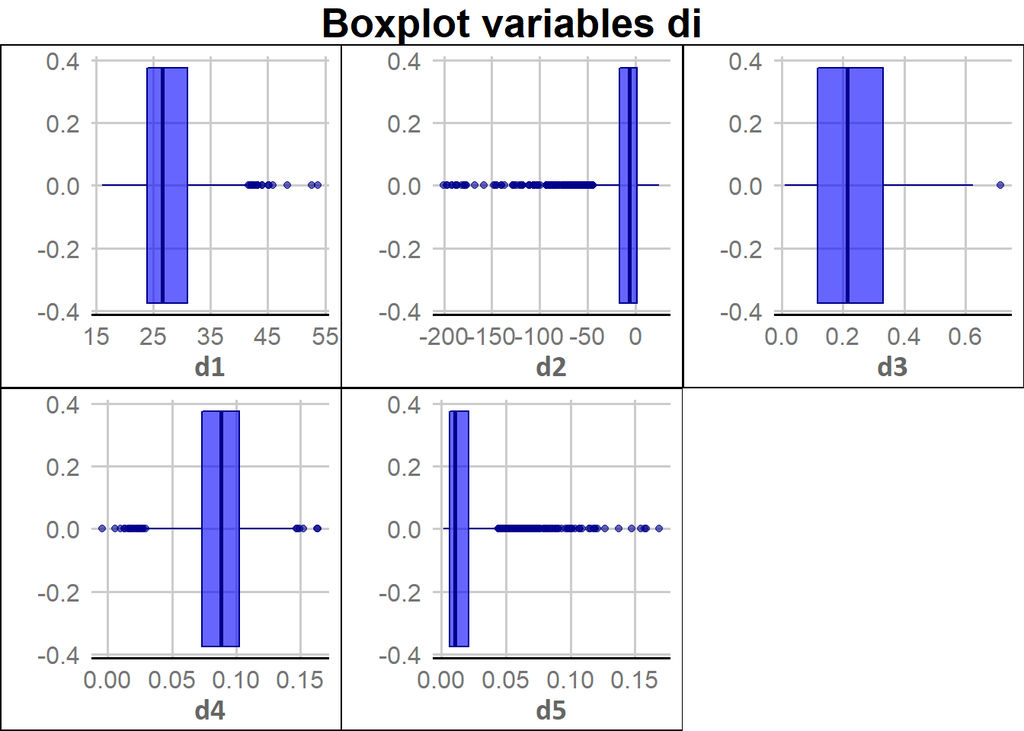

- En **d1** se tiene la mediana cercana a 25, y el 50% central de los datos parecen estar contenidos entre 25 y 30 aproximadamente. Hay gran presencia de valores extremos.
- En **d2** hay gran presencia de valores extremos por lo que se distorsiona el gráfico, posteriormente realizamos un zoom a la zona de interés.
- En **d3** la mediana pareciera estar cerca de 0.2 y el 50% central entre 0.1 y 0.3, aprozimadamente. Presenta un único valor extremo.
- En **d4** la mediana se encuentra cercana a 0.1, con el 50% central entre 0.08 y 0.1. Hay varios valores extremos.
- En **d5** hay gran presencia de valores extremos, por lo que realizamos un zoom para analizar.

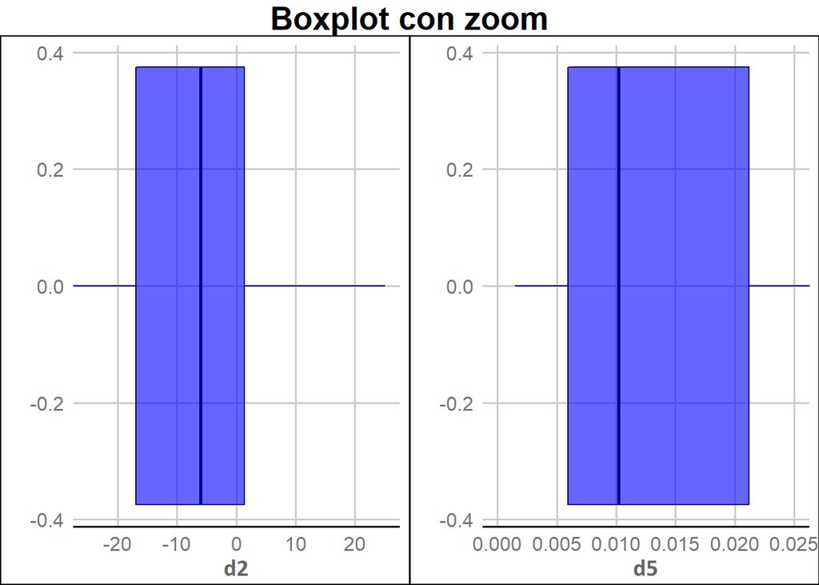

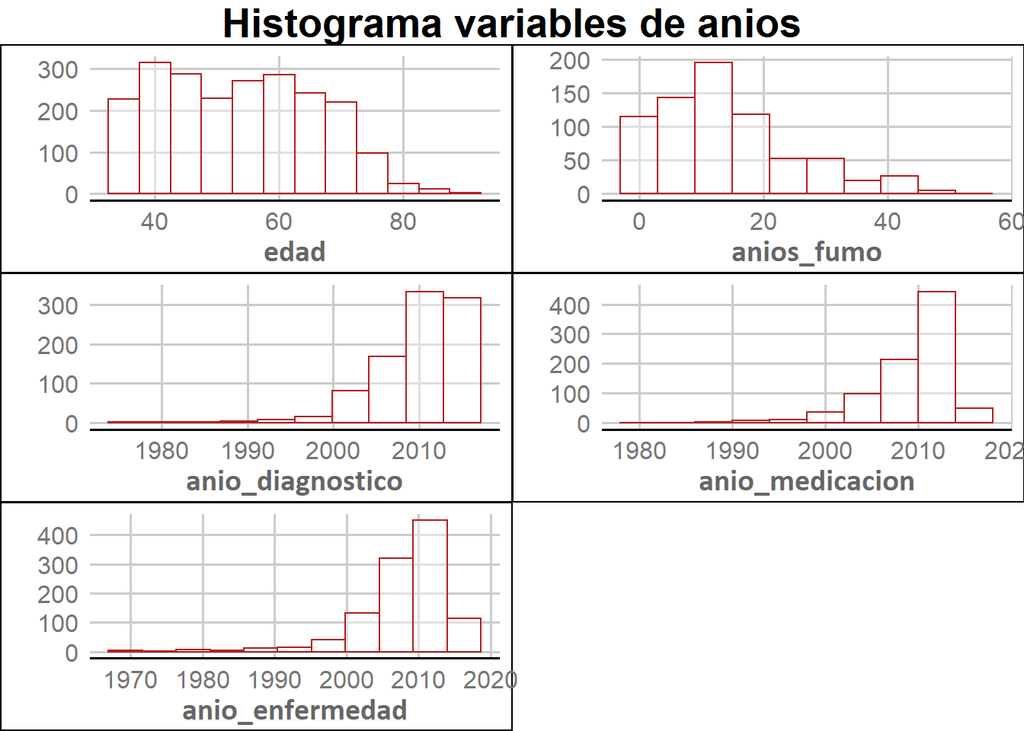

- En **edad** encontramos que las observaciones parecieran distribuirse uniformemente en el rango de 40 y 70, con algunas pocas observaciones extras para edades superiores a 70.
- En **anios_fumo** encontramos que existen observaciones de valores entre 1 y 50 prácticamente. Pero la mayo cantidad de observaciones se centran en los 15 años aproximadamente.
- En **anio_diagnostico** la mayor cantidad de observaciones se encuentran cerca del año 2010, pero existen algunas observaciones para los años menores a 2000.
- En **anio_medicacion** encontramos gran cantidad de observaciones cercanas al año 2010, y unas pocas para los años menores a 200.
- En **anio_enfermedad** la mayor cantidad de observaciones se encuentran cerca del año 2010, pero existen algunas observaciones para los años menores a 2000.

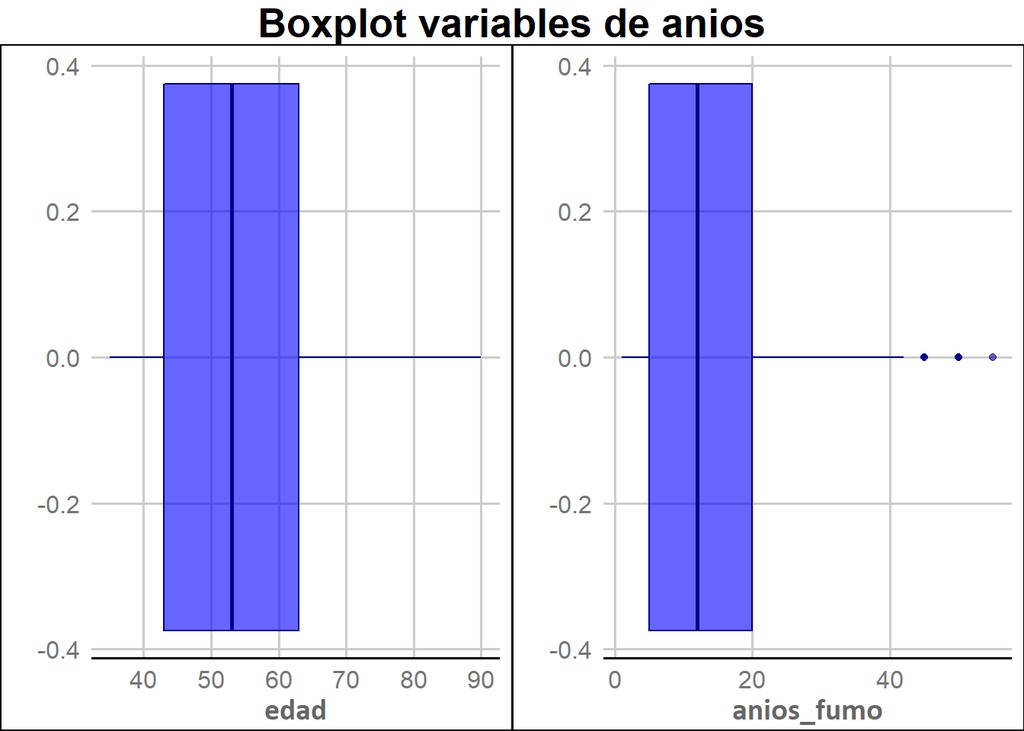

- En **edad** parece que la mediana se encuentra cercana a 52 años, con el 50% central de los datos desde los 45 hasta los 62 aproximadamente. No hay resencia de valores extremos.
- En **anios_fumo** la mediana parece encontrarse cerca de los 10 años. El 50% central de los datos va desde los 5 años hasta los 20. Existen algunos valores extremos.

| diagnostico | Freq |
| --- | --- |
| 0 | 1278 |
| 1 | 940 |

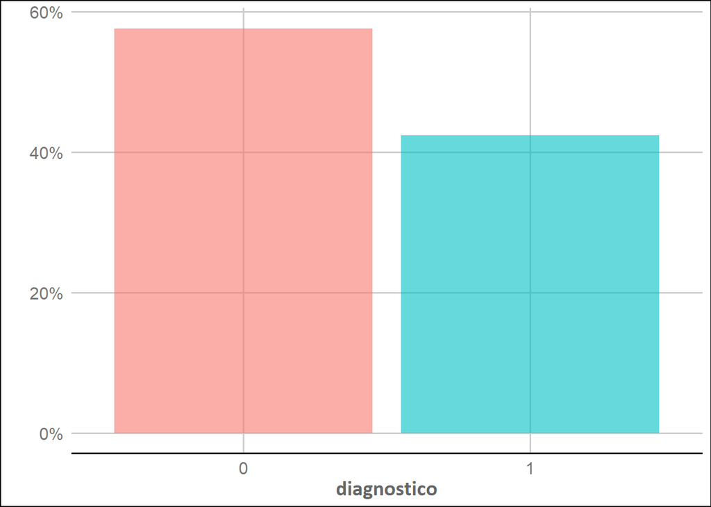

- En **diagnostico** más de la mitad de los datos corresponden a diagnósticos negativos, y el resto a diagnosticos positivos.

| punto_medicacion | Freq |
| --- | --- |
| Another time | 394 |
| I don’t take Parkinson medications | 1343 |
| Immediately before Parkinson medication | 209 |
| Just after Parkinson medication (at your best) | 255 |

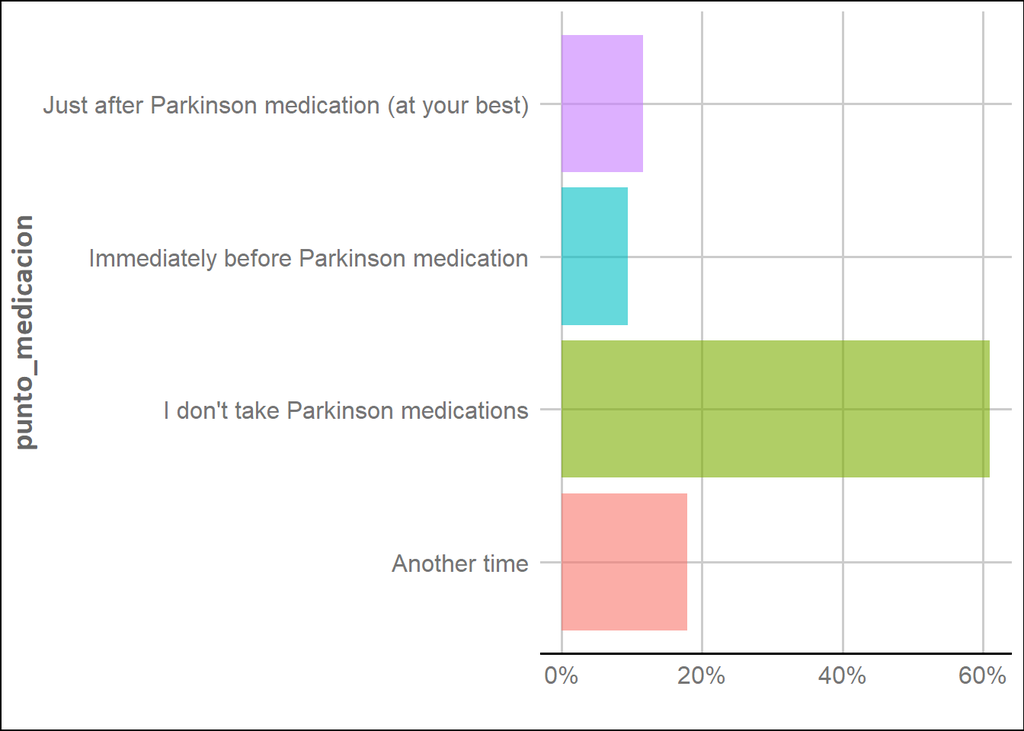

- En **punto_medicacion** el 60% de los datos corresponden a personas que no toman medicación para parkinson. Luego sigue, “Another time”, “Just After Parkinson medication” y “Immediately before Parkinson medication”.

| cuidado | Freq |
| --- | --- |
| false | 2075 |
| true | 140 |

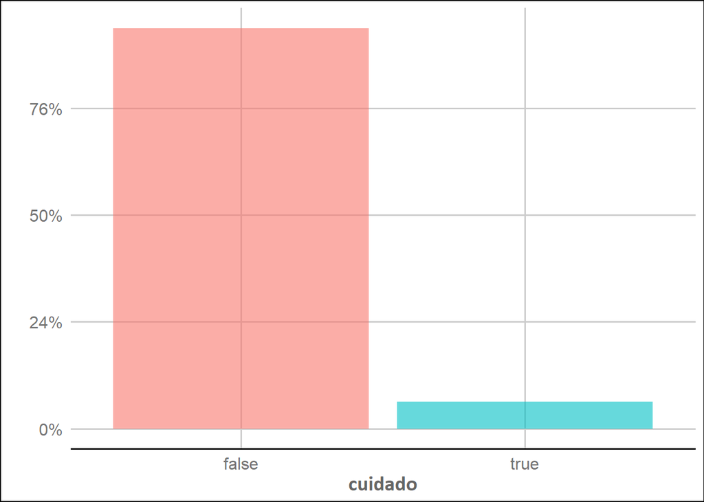

- En **cuidado** más del 80% de las personas se respondieron falso, casi el 5% si.

| DBS | Freq |
| --- | --- |
| false | 1850 |
| true | 100 |

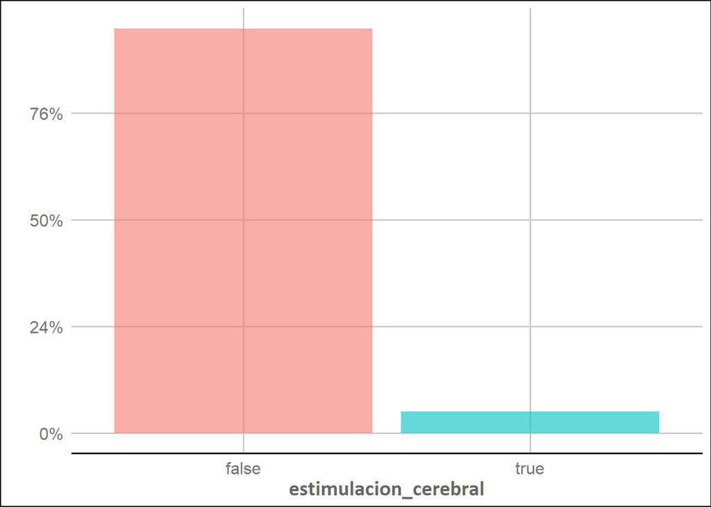

- En **estimulacion_cerebral** más del 80% de los datos respondieron fallos y el resto verdadero.

| educacion | Freq |
| --- | --- |
| 2-year college degree | 138 |
| 4-year college degree | 575 |
| Doctoral Degree | 295 |
| High School Diploma/GED | 115 |
| Masters Degree | 554 |
| Some college | 348 |
| Some graduate school | 171 |
| Some high school | 15 |

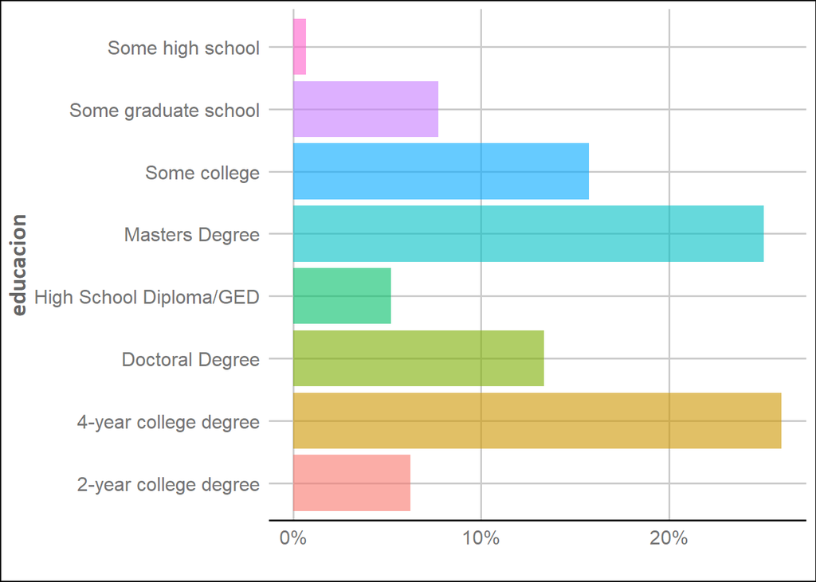

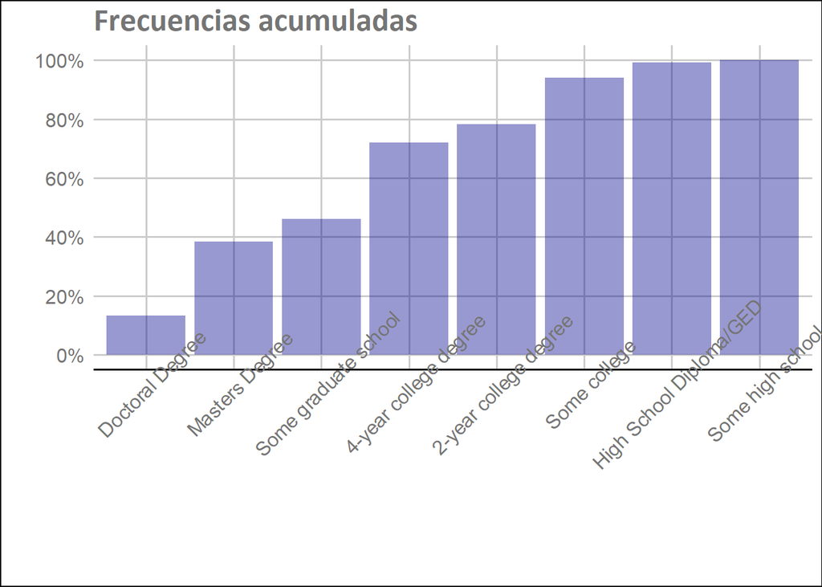

- En **educacion** se presenta la mayor cantidad de observaciones con “4-year college degree”, seguido por “Masters Degree”. En tercer lugar se tiene “Some college” y en cuarto “Doctoral Degree”.
- Además, en el gráfico de barra se ordeno por el nivel de educación, para observar como son la distribución de los datos. Aquí encontramos que hasta “2-year college degree”, es decir que tienen un título universitario, se acumula casi el 80% de los datos. Luego, si contamos “Some college” ya obtenemos más de los 90% de los datos.

| trabajo | Freq |
| --- | --- |
| A homemaker | 34 |
| A student | 10 |
| Employment for wages | 1117 |
| Out of work | 57 |
| Retired | 540 |
| Self-employed | 332 |
| Unable to work | 120 |

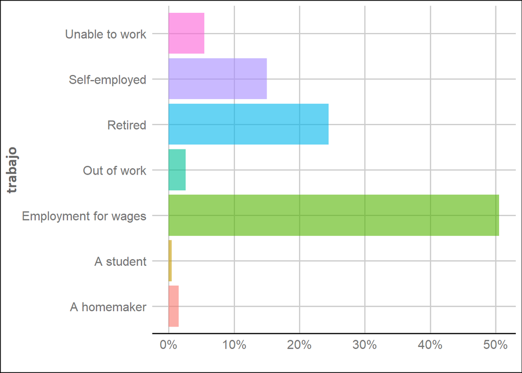

- En **trabajo** la mayor cantidad de los datos corresponden por “Empoyment for wages”, seguido por “Retired” y “Self-employed”.

| genero | Freq |
| --- | --- |
| Female | 574 |
| Male | 1641 |
| Prefer not to answer | 1 |

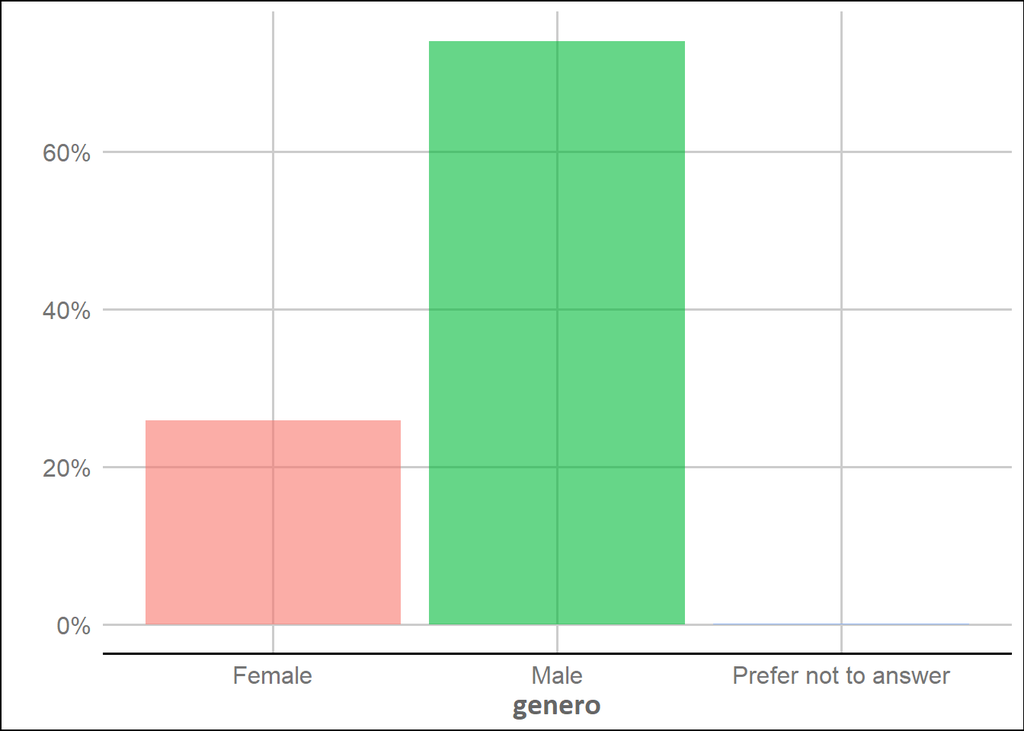

- En **genero** más del 70% de los datos corresponden a hombres, y un poco menos del 30% a mujeres.

| estado_civil | Freq |
| --- | --- |
| Divorced | 182 |
| Married or domestic partnership | 1735 |
| Other | 11 |
| Separated | 27 |
| Single never married | 209 |
| Widowed | 50 |

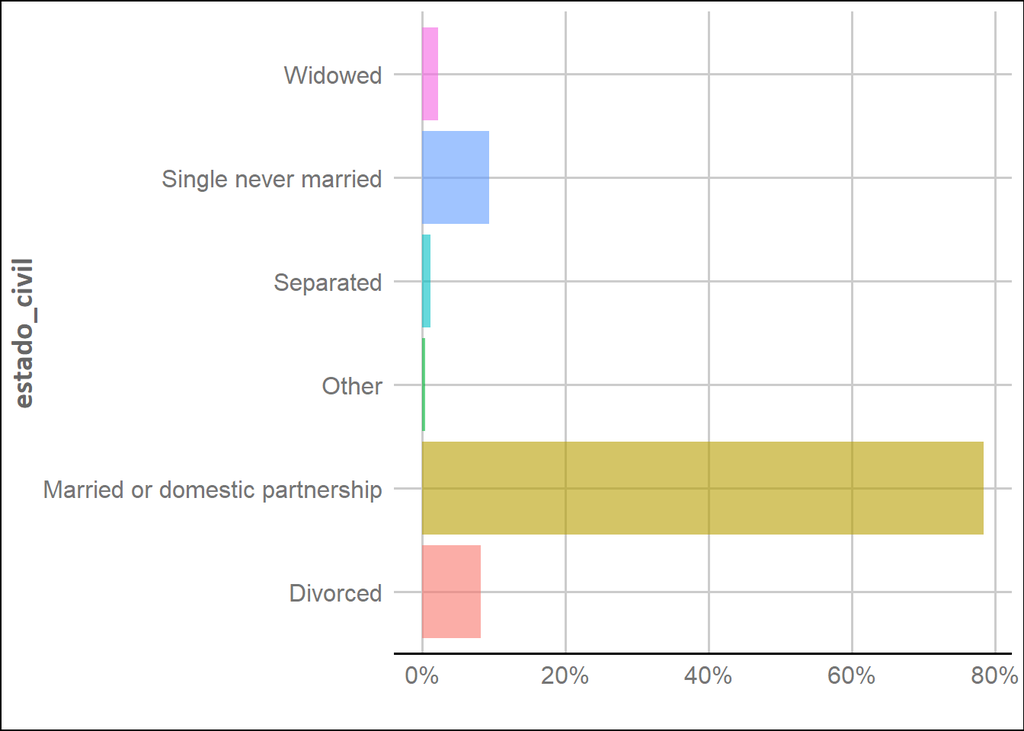

- En **estado_civil** casi el 80% de los datos se enceuntran en “Married or domestic partnership”. Luego, siguen “Single never married” y “Divorced” con menos del 10% cada uno. El resto se distribuyo entre el resto de categorías.

| facilidad_celular | Freq |
| --- | --- |
| Difficult | 35 |
| Easy | 436 |
| Neither easy nor difficult | 176 |
| Very Difficult | 8 |
| Very easy | 1562 |

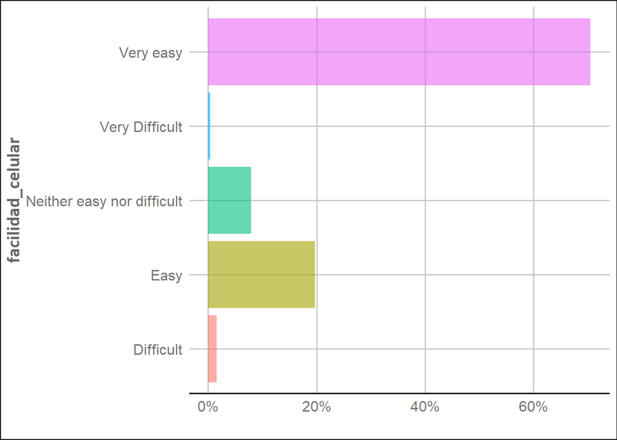

- En **facilidad_celular** el 70% de los datos coresponden a “Very easy”, un 20% a “Easy”, menos del 10% a “Neither easy nor dificult” y el resto a las demás categorías.

| fumo | Freq |
| --- | --- |
| false | 1375 |
| true | 778 |

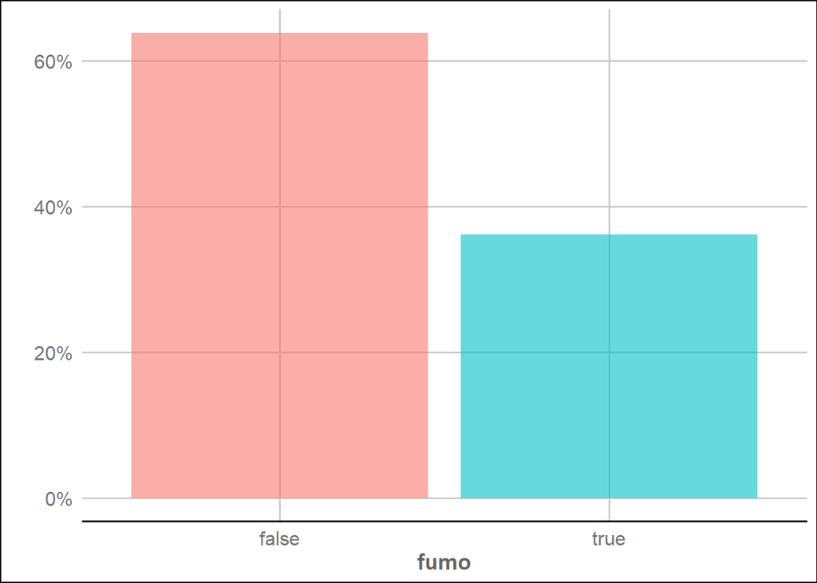

- En **fumo** encontramos que más del 60% de los datos corresponden a falso y un poco más del 30% a verdadero.

| cirugias | Freq |
| --- | --- |
| false | 1822 |
| true | 13 |

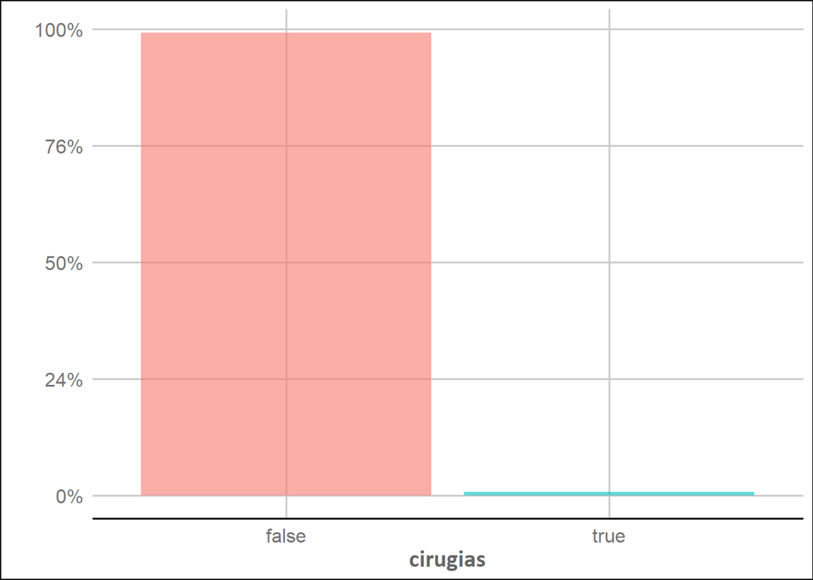

- En **cirugas** casi el 100% de los resultados corresponden a falos y un pequeño porcentaje a verdadero.

## Análisis Multivariado

### Cualitativa vs cuantitativa

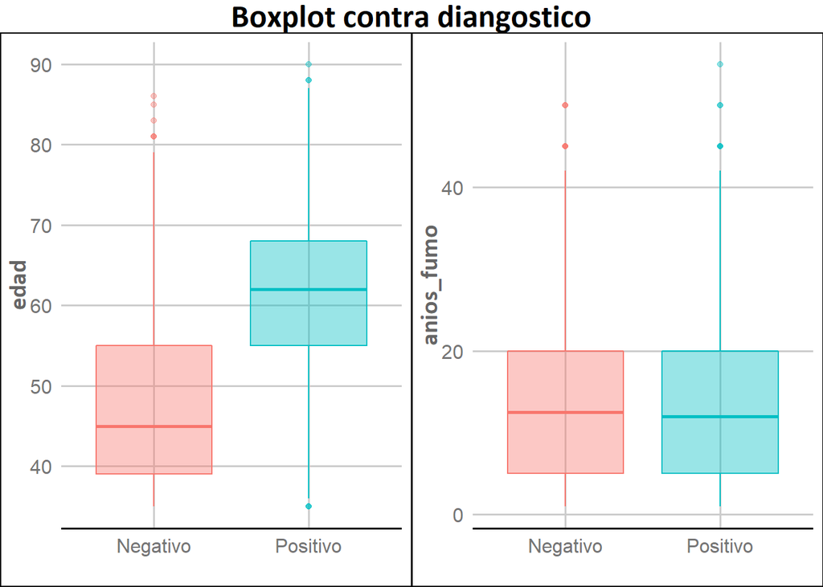

- Se sugiere que la **edad** de las personas con diagnostico positivo es mayor a la edad con diagnostico negativo. Siendo la mediana de los primeros un poco superior a 60 años y 45 años para los segundos. Por el otro lado, **anios_fumo** no parece tener diferencia entre los paciente con diagnostico positivos y negativo.

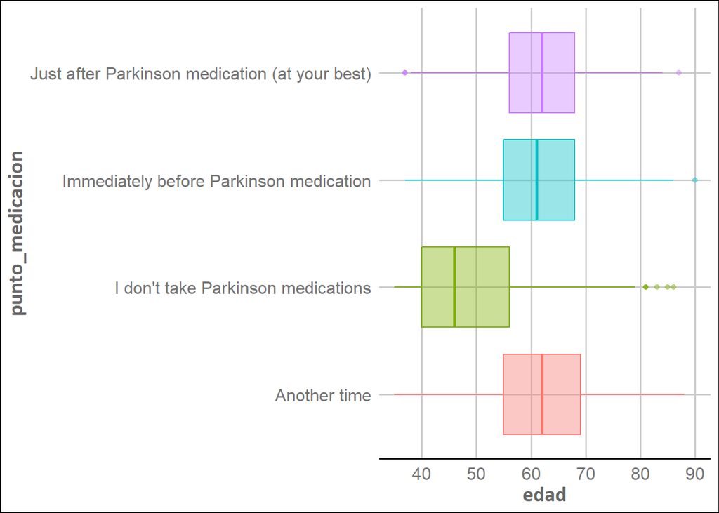

- Se observa como la **edad** parece ser menor en el caso de “I don’t take Parkinsons medications” y los demás niveles son casi idénticos. Sin embargo, comparando con el gráfico previo de **edad** vs **diagnostico** se observa como las edades de las personas que tienen un diagnostico negativo son bastante similares a las edades de este grupo en particular. Entonces capaz que las personas de este grupo sean las que tienen un diagnostico negativo.

Realizamos la tabla de contingencia entre **diagnostico** contra **punto_medicacion** para verificar que las personas de “I don’t take Parkinsons medications” son las que tienen un diagnostico negativo.

|  | 0 | 1 |
| --- | --- | --- |
| Another time | 0 | 394 |
| I don’t take Parkinson medications | 1267 | 76 |
| Immediately before Parkinson medication | 0 | 209 |
| Just after Parkinson medication (at your best) | 0 | 255 |

Aqui verificamos que la gran mayoría del segundo grupo tienen diagnóstico negativo (casi el 95%) y el resto positivo.

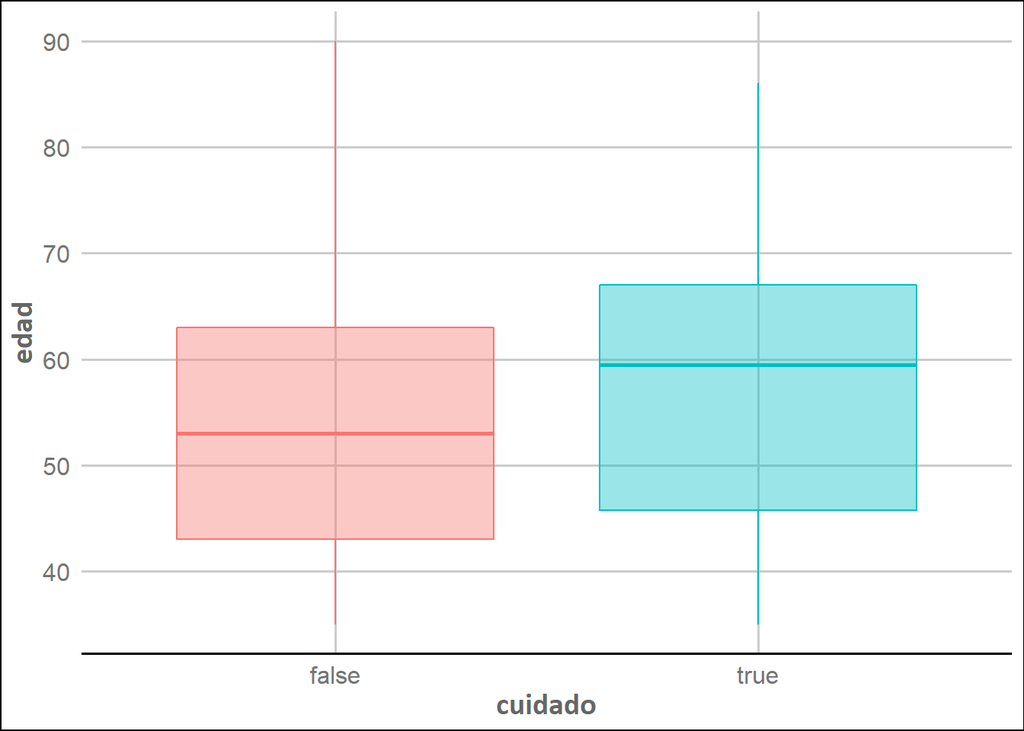

- No parece existir diferencia de edades entre los dos grupos.

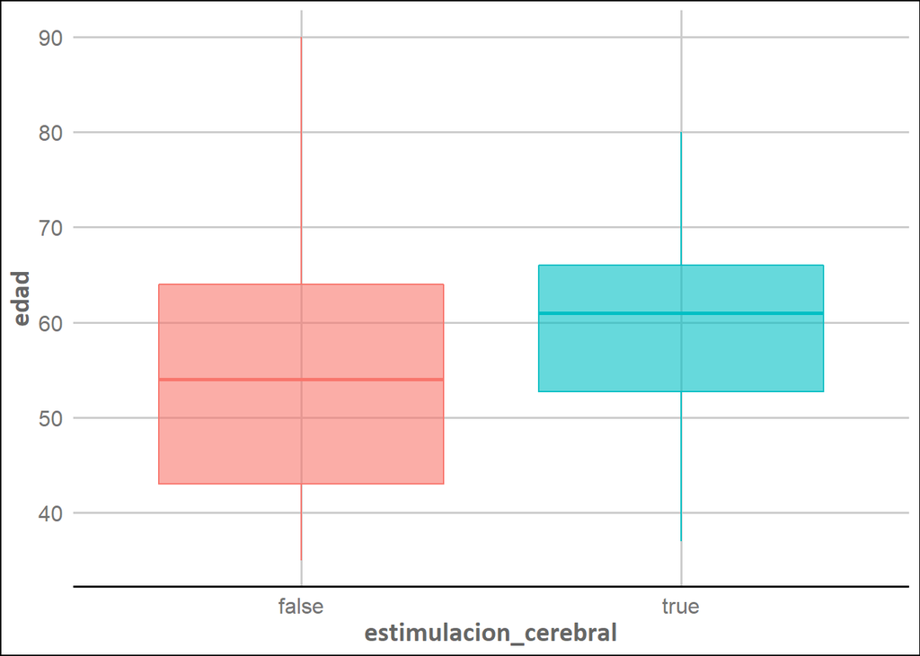

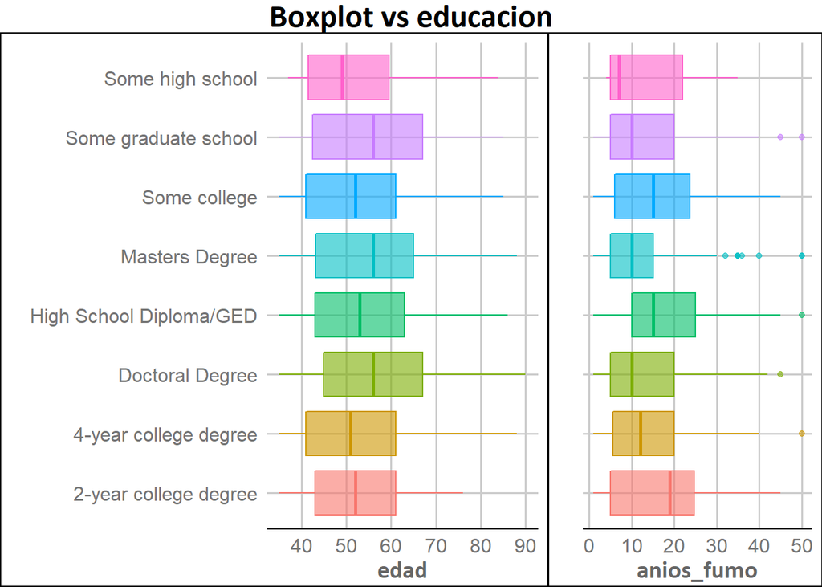

- En general, parece que todos los grupos presentan edades similares, aunque “Some graduate school” pareciera que la variabilidad es mayor.
- Para **anios_fumo** parece que es similar para todos los grupos, pero el grupo “Masters Degree” presenta menor variablidad. En contraste “2-year college degree” es el grupo con mayor variabilidad.

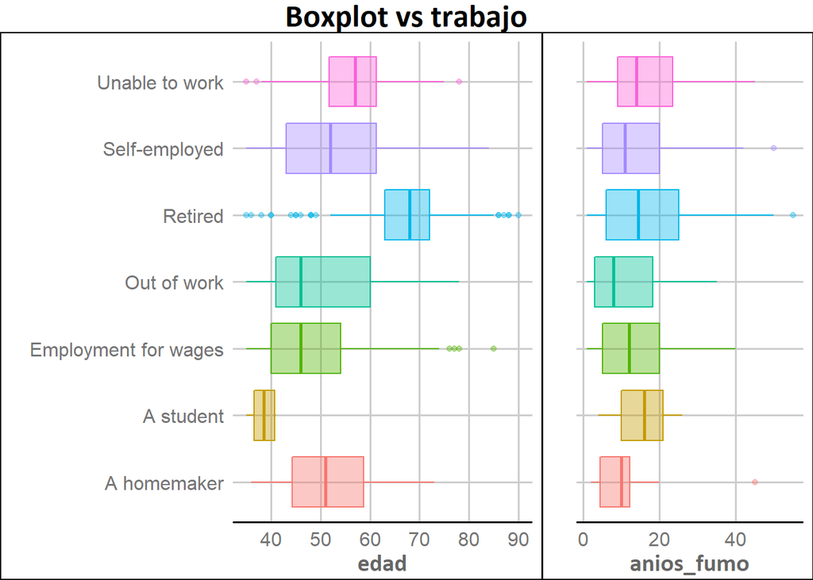

- El grupo de “A student” pareciera presentar edades menores al resto de grupos. A su vez “Retired” son los que tienen mayor edad, aunque encontramos varios valores extremos. El resto de grupos tienen edades intermedias, y en general presentan valores parecidos aunque la variabilidad cambia.
- En el segundo gráfico, todos los grupos presentan una cantidad de años que fumo similares. Aunque el grupo “A student” presenta edades menores al resto, **anios_fumo** es similar al de resto de grupos.

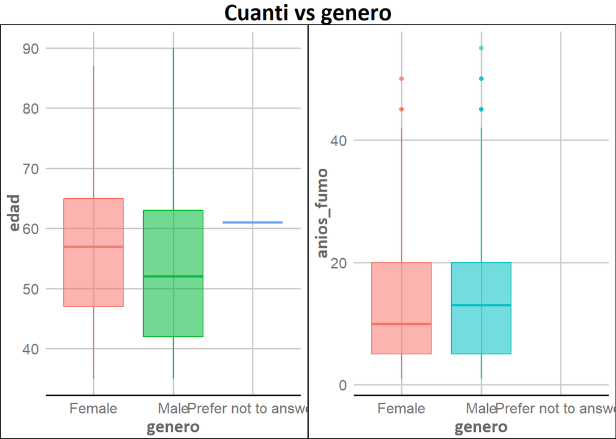

- No parece haber diferencia entre hombres y mueres en cuanto a la **edad** y **anios_fumo**

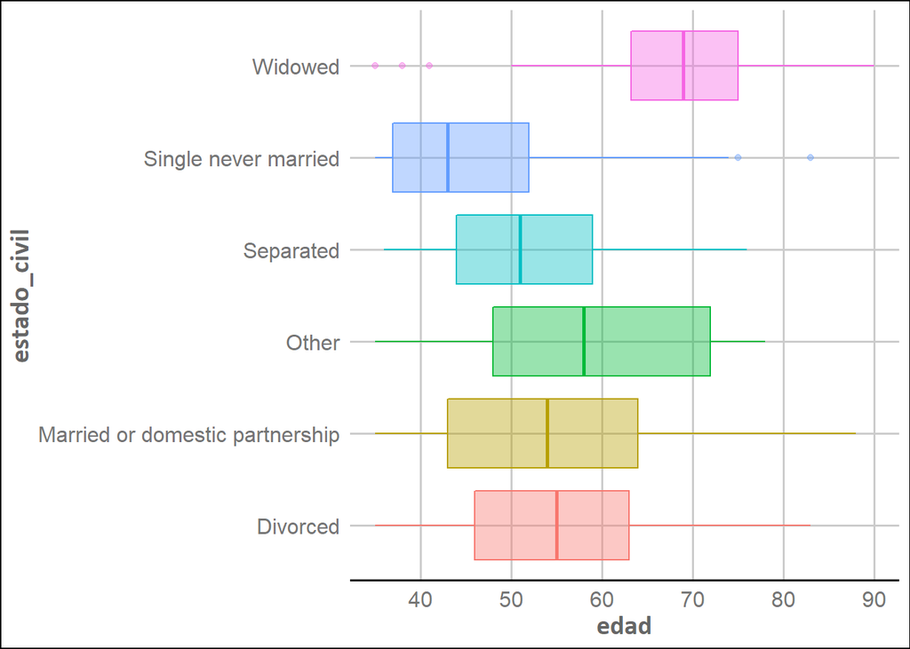

- El grupo “Single never married” presenta una edad mediana menor al primer cuartil del resto de los grupos. A su vez el grupo “widowed” presenta el primer cuartil superior al tercer cuartil del resto de grupos, excepto “Other”.

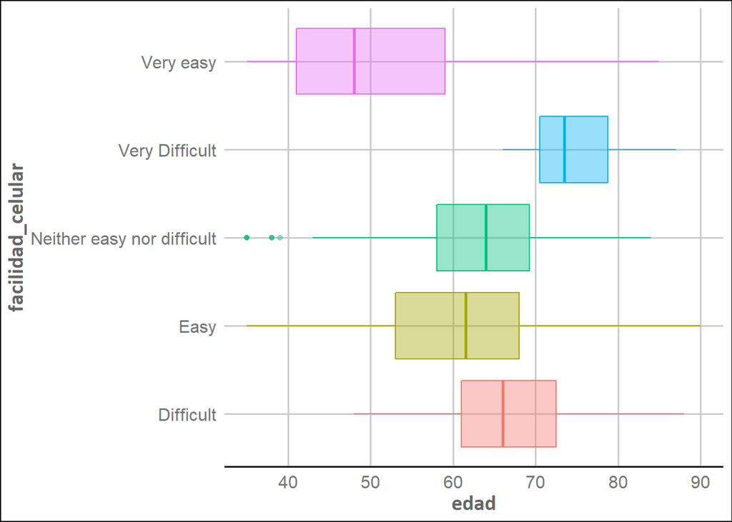

- El grupo “Very easy” presenta una edad mediana menor al primer cuartil del resto de los grupos. En cambio, el grupo “Very Difficult” presenta una edad mediana mayor al tercer cuartil del resto de grupos. Sin embargo, los tres grupos restantes presentan edades similares, teniendo a los grupos de “Easy” y “Difficult” aqui.

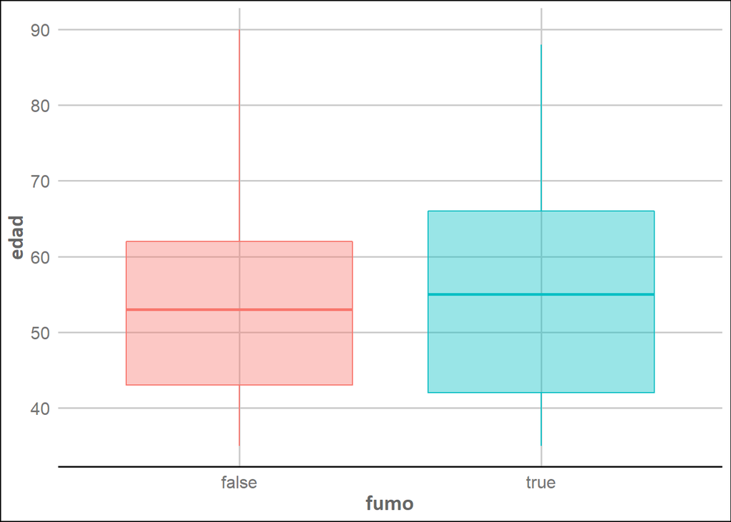

- No parece haber diferencia de edades entre ambos grupos.

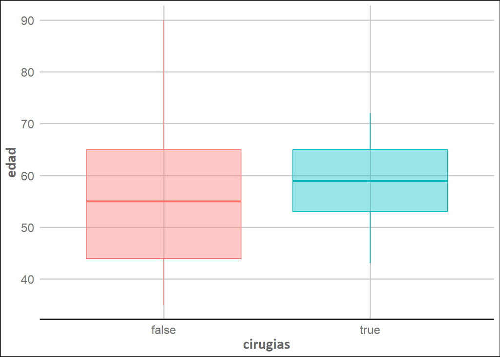

- No parece haber diferencias de edades entre ambos grupos, pero el grupo que si tiene cirugías presenta menor variabilidad que el otro.

### Cualitativa vs Cualitativa

|  | 0 | 1 | Sum |
| --- | --- | --- | --- |
| false | 1206 | 869 | 2075 |
| true | 70 | 70 | 140 |
| Sum | 1276 | 939 | 2215 |

- Del grupo con diagnóstico negativo, el 94.45% no presenta cuidados y el resto si. Por le otro lado, para el grupo con diagnostico positivo presenta un 92.25% no presenta cuidado y el resto si.
- Del grupo que no tiene cuidado, el 58.12% presenta diangostico negativo, y el resto diagnóstico positivo. Por el otro lado, para el caso del grupo con cuidado, los datos se reparten exactamente a la mitad entre personas con diagnóstico positivo y negativo, es decir que hay un 50% para cada uno. Se observa como en estos casos la distribución de observaciones es más equitativa que cuando se miraban las columnas.

|  | 0 | 1 | Sum |
| --- | --- | --- | --- |
| false | 1007 | 843 | 1850 |
| true | 6 | 94 | 100 |
| Sum | 1013 | 937 | 1950 |

- Del grupo con diagnóstico negativo, el 99.4% no se realiza el tratamiento DBS y el resto si.
- Del grupo con diagnóstico positivo, el 89.96% no realiza el tratamiento de DBS y el resto sí.
- Del grupo que no realiza el tratamiento DBS, el 54.43% presenta diágnostico negativo y el resto positivo. La distribución de las osbservaciones es más equitativa en este caso.
- Del grupo que si realiza el tratamiento DBS, el 94% presenta diágnostico postivo y el resto negativo. Esto puede tener causa en que este tratamiento es usado generalmente en pacientes de Parkinson.

|  | 0 | 1 | Sum |
| --- | --- | --- | --- |
| 2-year college degree | 81 | 57 | 138 |
| 4-year college degree | 332 | 243 | 575 |
| Doctoral Degree | 166 | 129 | 295 |
| High School Diploma/GED | 57 | 58 | 115 |
| Masters Degree | 313 | 241 | 554 |
| Some college | 218 | 130 | 348 |
| Some graduate school | 97 | 74 | 171 |
| Some high school | 10 | 5 | 15 |
| Sum | 1274 | 937 | 2211 |

- En este caso, vamos a realizar dos diagramas de barras para mostrar como son la distribución de observaciones cuando se agrupa según el **diagnostico**

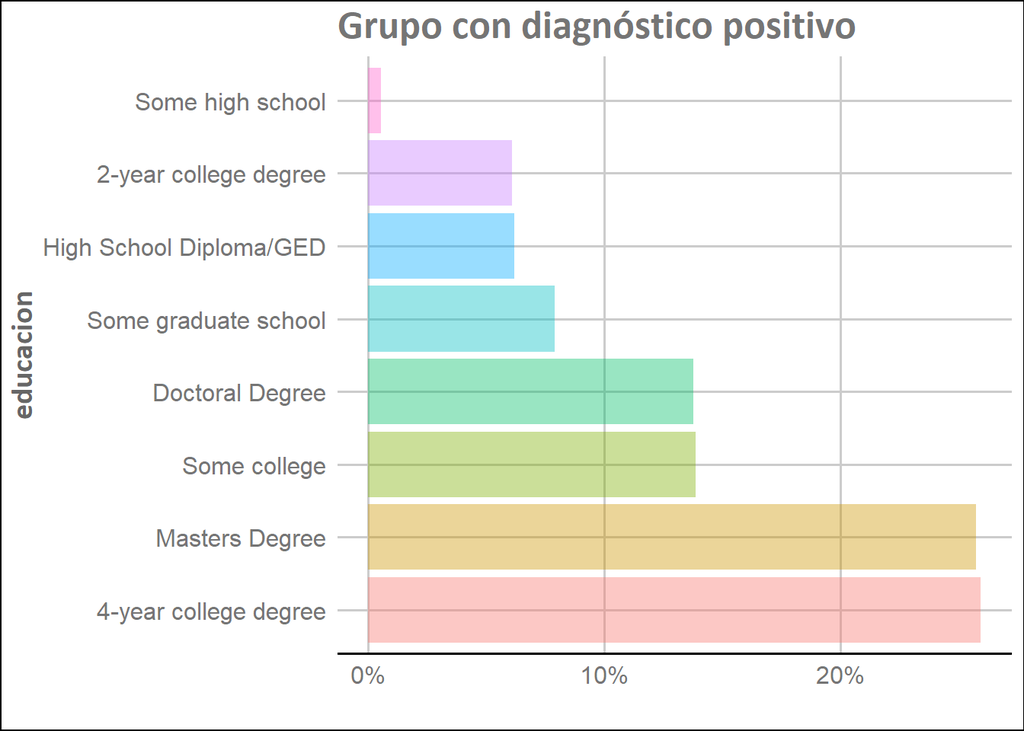

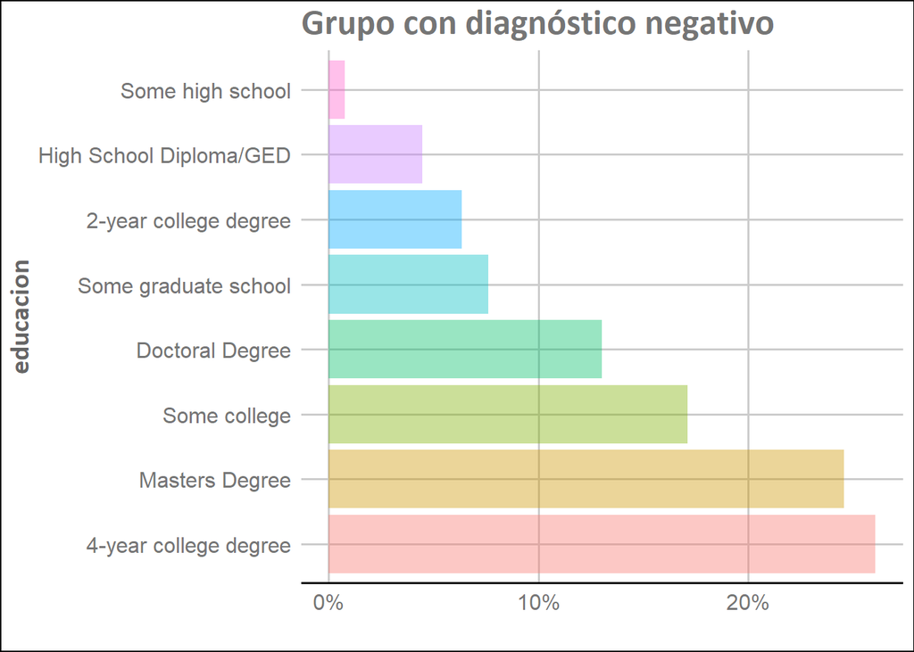

- Se presentan resultados similares que en el caso de grupo con diagnóstico positivo.

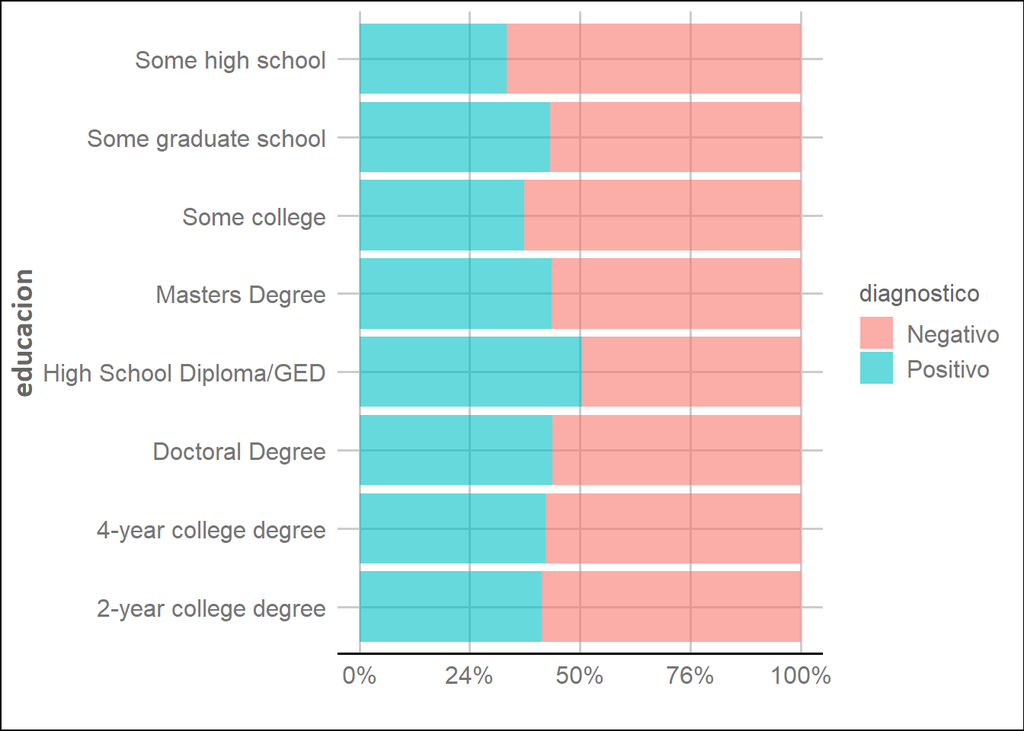

- Se observa como todos los niveles de educación presentan porcentajes parecidos de personas con porcentajes negativos/postivos. El caso de “High School Diploma” que tiene los datos repartidos equitativamente.

|  | 0 | 1 | Sum |
| --- | --- | --- | --- |
| Female | 242 | 332 | 574 |
| Male | 1034 | 607 | 1641 |
| Prefer not to answer | 1 | 0 | 1 |
| Sum | 1277 | 939 | 2216 |

|  | 0 | 1 | Sum |
| --- | --- | --- | --- |
| Difficult | 3 | 32 | 35 |
| Easy | 119 | 317 | 436 |
| Neither easy nor difficult | 13 | 163 | 176 |
| Very Difficult | 1 | 7 | 8 |
| Very easy | 1141 | 421 | 1562 |
| Sum | 1277 | 940 | 2217 |

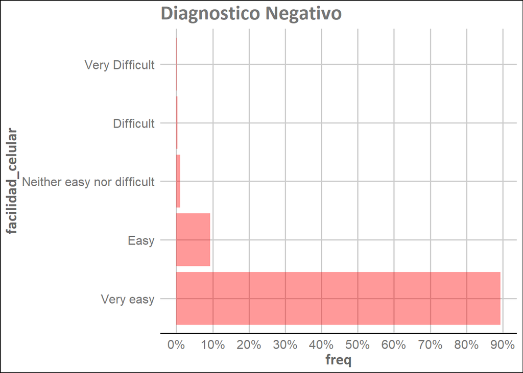

- Se observa que casi el 90% de las personas con diagnóstico negativo se encuentran en “Very easy” y casi un 10% en “easy”.

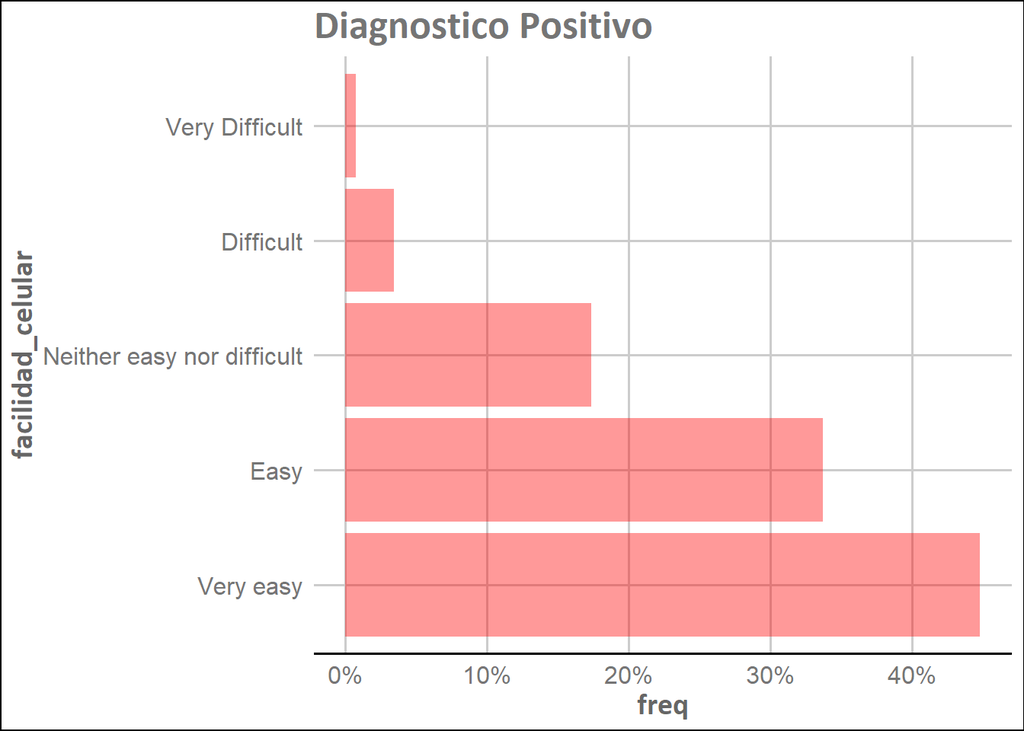

- Si bien se presenta un orden de grupos idéntico al caso anterior, aquí los grupos “Neither easy nor difficult”, “Difficult” y “Very difficult” adquirien más relevancia en este grupo.

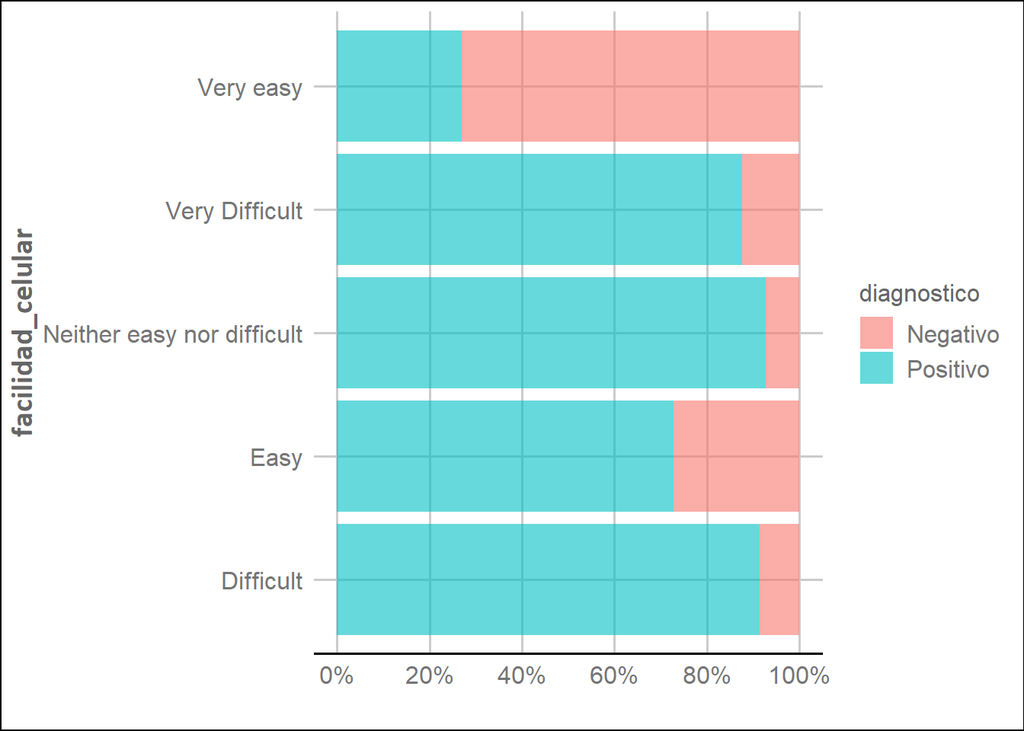

- Se observa como en todos los grupos, menos en “Very easy”, se más del 60% de las personas con diagnóstico postivo. En “Very easy” ocurre lo contrario, la mayoría de las personas corresponden a diagnóstico negativo.

|  | 0 | 1 | Sum |
| --- | --- | --- | --- |
| false | 759 | 616 | 1375 |
| true | 455 | 323 | 778 |
| Sum | 1214 | 939 | 2153 |

|  | 0 | 1 | Sum |
| --- | --- | --- | --- |
| false | 894 | 928 | 1822 |
| true | 2 | 11 | 13 |
| Sum | 896 | 939 | 1835 |

- Del grupo con diagnóstico negativo el 99.77% no presenta cirugías. En el grupo con diagnóstico positivo ocurre algo similar, hay un 98.82% de las personas sin cirugías.
- Del grupo sin cirugías, el 49.06% tienen diagnóstico negativo y el resto positivo. Se observa que los datos se encuentran repartidos equitativamente.
- Del grupo con cirugías, el 15.38% tienen diagnóstico negativo y el resto postivio. Aqui encontramos que predominan las personas con Parkinson.

## Análisis cuanti vs cuanti

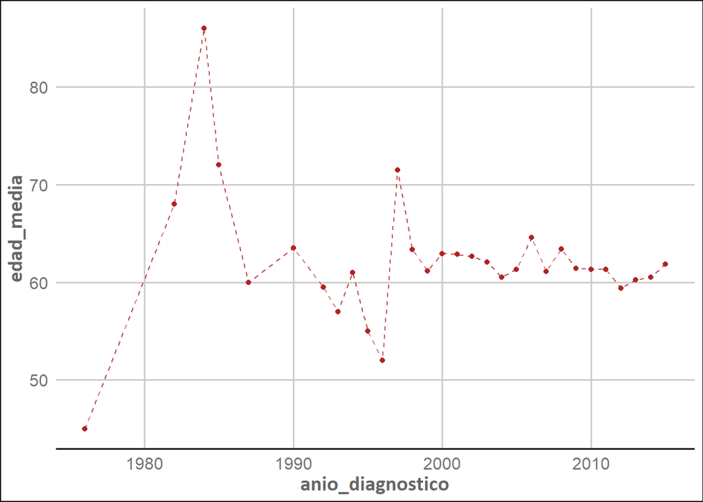

- Parece que al comienzo las edades medias varían considerablemente, desde casos con edades medias bajas o muy grandes. A partir del 200 parece que se estabiliza la edad media.

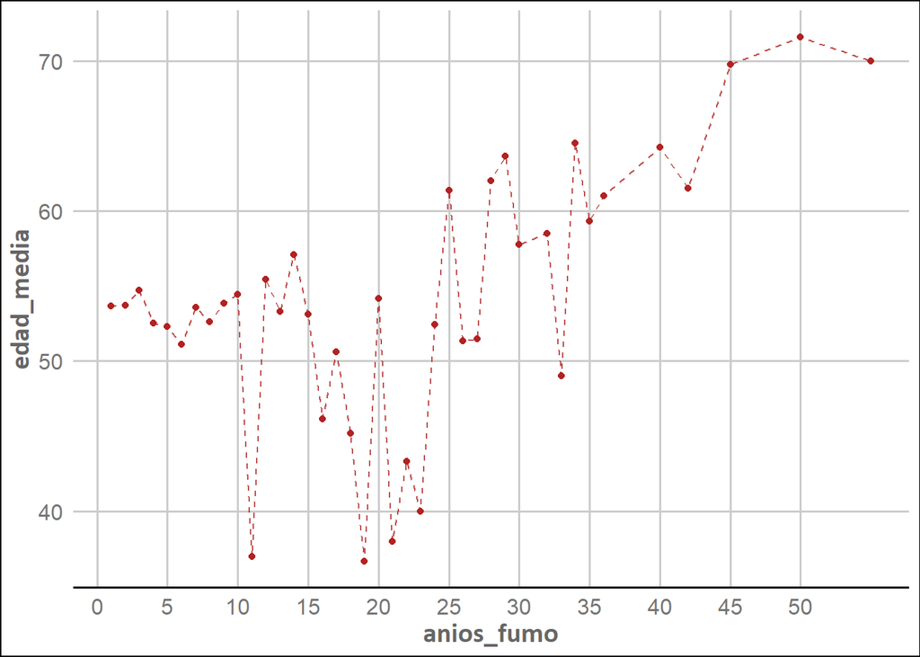

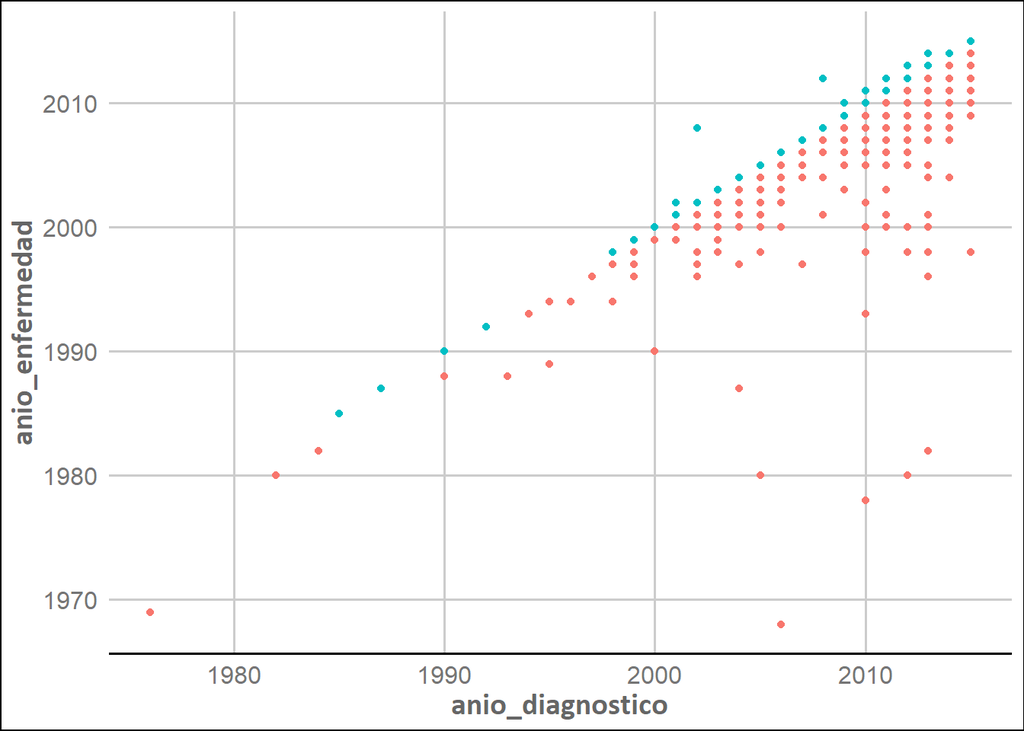

- Se observa que los puntos rojos pertenecen a los casos en que la persona recibió un diagnóstico luego de que se manisfestará la enferemdad.

Definimos una nueva variable lamada **punto_enfermedad** para boservar la cantidad de casos en que el diagnóstico ocurrió luego de que se manifestará la enfermedad.

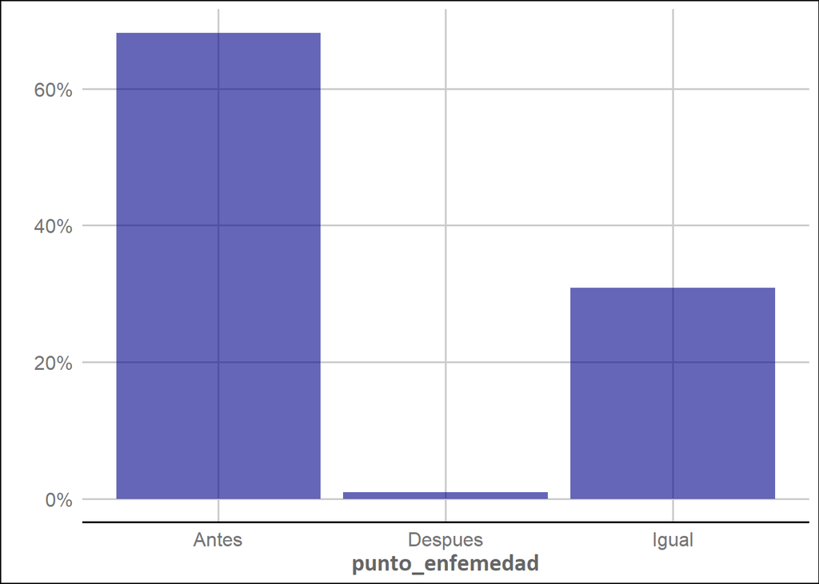

- Más de la mitad de los casos recibieron el diagnóstico en años posetirores a que se manifesterá la enfermedad. En aproximadamente el 30% de los casos estos eventos ocurrieron en el mismo año. Y un pequeño procentaje primero recibio el diagnóstico.